# Intro to R and Resources

Grace Avecilla

June 2019

# 1 Getting Started with R

R is a language and environment for statistical programming. Using R, you can read in data, clean data, manipulate data, do a wide variety of statistical tests, and visualize your data using many different graphical techniques. It is a high level language that is widely used throughout many sciences, but especially biology, with a large community and a lot of support.

We will be using R throughout this course to manage, perform statistical tests on, and visualize our data.

## 1.1 Download R & RStudio

R is available for **free** at r-project.org. There’s versions for Windows, Mac, *nix. Download and install it. You can open it to see if it worked. You enter commands by typing them and pressing enter. R should spit back a response of some kind. One thing you can do is type `version` and hit enter. It’ll respond with the version. You should have downloaded the latest version, around 3.5.1 or later.

R itself is pretty minimal, so we’ll want to download [RStudio](https://www.rstudio.com/products/rstudio/download/) as well. RStudio is a graphical user interface (GUI) integrated development environment (IDE) for using R. RStudio will make it easier for us to write and edit our code, view plots, and make documents like this one. RStudio Desktop is also free.

## 1.2 Getting started using R

When you open RStudio, you’ll see a Console that looks like the console you used when you downloaded R. On the right you should see an Environment window and a Files window. Does the contents of the Files window look familar? It should be your home directory, however that’s defined on your system.

The console is how you use R. Try typing things in the console window. You enter commands by typing the line, then pressing enter. Try the following:

```r
print('hello world')
```

```
[1] "hello world"
```

```r
2+2
```

```
[1] 4
```

Try typing in whatever else comes to mind, see what happens. It is hard to break anything, so give it a go. You can go back to a previous command by pressing the UP arrow, and you can modify it or just run it again with hitting enter.

*Tab completion*

If you start to type any name in the R console and press TAB, R will look for all the possible things you could mean (ie things that start with the letters you just typed), and will complete or prompt you will possible sensible completions. If you don’t see anything with one TAB, double TAB it. You should see a list of options. Try this by typing `ag` and TAB a few times. Then type an additional `g` to get `agg` and then press TAB. It should complete it to `aggregate`. Press TAB again and you can see all the things that start with `aggregate`.

Autocompletion speeds you up, reminds you of what you may have forgotten, and prevents typos.

*Get organized.*

Make yourself a folder for this work, I’ll assume it’s called “introR” but you can call it whatever you like. AVOID using spaces, use _ (my_directory) or CapitalizeEachWord (ThisIsCalledCamelCase). Why no spaces? They’re harder to type for when navigating directories from within R. Give directories informative names, it’ll help you later on. Use consistent naming schemes, choose either CamelCase or underscores.

**If you want to follow along with this code, get the .Rmd file for this document**  
It is called SURP_Intro_to_R.Rmd  
Save it in the folder you just made.

Let’s get to this folder so we can access this file. First, let’s see what directory we are in. You can see where you are by using `getwd()`.

Now, let’s get to the directory we want to be in. The directory path is a little different depending on your operating system. You can use tab completion to view directories available and autocomplete your choices.

```r
#for Mac OS, or *nix
setwd("/Users/grace/R_teaching/introR")
#note ~ is equivalent to /home so the following should also work
setwd("~/grace/R_teachign/introR")

#for Windows
#may be slightly incorrect
setwd("C:\MyDocuments\R_teaching\introR")
```

You can go up a directory using `..` (for example, `setwd('..')` would change the directory I’m in to R_teaching).

Finally, view the contents of the directory you’re in using `dir()`. You should see SURP_Intro_to_R.Rmd

# 2 Reproducible Research

What is reproducible research?

Why is reproducible research important?

**Comment your code.**

`#comment a line of code using a hash`

Make inline comments descriptive and succint. There’s a balance between too little commenting and too much. If it is obvious what you’re doing from the line of code, you don’t have to repeat that in the comment.

`#get the average value in the dataset`  
`mean(data)`  
That’s not useful.

**Use R Notebooks**

R Notebooks and other R Markdowns allow you to use a single document to both:

- save and execute code
- generate high quality, readable reports that can be shared with others

They facilitate sharing and reuse of code, and are easier to read and interpret than only code.

## 2.1 Packages

Practical R usage revolves around packages.  
These are nicely packaged bits of software which are developed with regular interfaces to use in R. These facilitate re-use of code that is written well, instead of everyone writing their own non-optimized code.

We are going to install a package that allows us to use R Notebooks using `install.packages('rmarkdown').`

You may be prompted to choose a mirror - this is which website you download from and you should pick the geographically closest one – or just the one with “cloud” in it.

We’ll then load the package using `library('rmarkdown')`.

## 2.2 Rendering a markdown

Now you should be able to typeset the .Rmd you downloaded from NYU Classes by entering `render("SURP_Intro_to_R.Rmd")` into the console. If it completed without any errors, it should report `Output created: SURP_Intro_to_R.html` and you should be able to open that .html document using a web browser.

## 2.3 Make a new R notebook

The easiest way to make a new notebook is the following:  
*File –> New File –> R Notebook*  
This will produce a new file specified by the YAML (Yet Another Markup Language).

This should give you a template document with a lot of things already filled in and the file suffix set properly.

You should change the YAML at the top to reflect the thing that you’re doing. R code goes inside chunks, and you can write text outside of those. You can add a new chunk by *Cmd+Option+I* or by using the toolbar on top.

Try changing some things in the notebook. Check to see your changes using the Preview button on the top - *while the notebook preview looks similar to an executed R Markdown document, the notebook preview does not execute any of your R code chunks.* It simply shows you a rendered copy of the Markdown output of your document along with the most recent chunk output. This preview is generated automatically whenever you save the notebook.

Knit the notebook using the *Knit to HTML*. These will execute code chunks and well as rendering the file.

You will submit your homework as the rendered HTML notebooks.**Run your code chunks before you render the notebook.**

# 3 Data in R

Now that you’re able to keep neat, reproducable notes of your work, let’s get into the R a bit more.

## 3.1 R can be used as a fancy calculator

R is fundamentally a fancy calculator. Try these operations by typing them into the Console and pressing enter. You should see a similar output as described here.

```r
2+2
```

```
[1] 4
```

```r
2+3
```

```
[1] 5
```

```r
2-3
```

```
[1] -1
```

```r
8*2
```

```
[1] 16
```

```r
6/3
```

```
[1] 2
```

```r
2^3
```

```
[1] 8
```

```r
20%%8
```

```
[1] 4
```

Ever seen that last one, `%%`? It’s called a modulus.  
Probably not necessary for this course, but a cool operator that gives you the remainder from a division.

## 3.2 Variables

Defining variables, or giving a name to values, allows you to store information.

You define variables using the `<-` operator, which means “store the value on the right in the variable on the left”, like so. You can then call it back by saying the variable name. Variable names should be short and informative, are case sensitive, and should not have spaces.

You can use variables in the place of numbers, and perform mathematical operations on them.

```r
variable1 <- 3
variable2 <- 2
variable1
```

```
[1] 3
```

```r
variable1-variable2
```

```
[1] 1
```

R can also store text. These are in the form of strings of characters. Surround characters in quote marks to have them be character strings and not variable names.

```r
char <- "a"
char
```

```
[1] "a"
```

```r
char_sentence <- "My favorite food is ice cream"
char_sentence
```

```
[1] "My favorite food is ice cream"
```

```r
char_variable1 <- "variable1"
char_variable1
```

```
[1] "variable1"
```

```r
char_variable2 <- variable1
char_variable2
```

```
[1] 3
```

You can list all the variables you currently have open by entering `ls()` into the console.

## 3.3 Data types in R

As you have seen, there are different types of data in R. So far we have created numeric and character variables. We can illustrate that these variables are different types:

```r
is(char_variable1)
```

```
[1] "character"           "vector"              "data.frameRowLabels"
[4] "SuperClassMethod"
```

```r
is(char_variable2)
```

```
[1] "numeric" "vector"
```

We can also coerce variables between types.

```r
char_variable2
```

```
[1] 3
```

```r
char_variable3 <- as.character(char_variable2)
char_variable3
```

```
[1] "3"
```

```r
is(char_variable3)
```

```
[1] "character"           "vector"              "data.frameRowLabels"
[4] "SuperClassMethod"
```

```r
is(as.numeric(char_variable3))
```

```
[1] "numeric" "vector"
```

Note that you can put functions inside of other functions. While less readable, it saves you having to make a new variable.

## 3.4 Vectors

Vectors are the most basic kind of variable in R, and are basically just a set of numbered bins in which to put values. If you’ve noticed everything R prints back has been preceeded by a [1]. That’s because the most fundamental unit of variable in R is a length-one vector.

We can define a longer vector with the `c()` notation, a series of numbers with a `:`, report the length of a vector with `length()`, and access a particular position with `[]` notation.

```r
vector1 <- c("thing1", "thing2", "thing3")
is(vector1)
```

```
[1] "character"           "vector"              "data.frameRowLabels"
[4] "SuperClassMethod"
```

```r
length(vector1)
```

```
[1] 3
```

```r
vector1[1]
```

```
[1] "thing1"
```

```r
vector2 <- c(2, 4, 6)
is(vector2)
```

```
[1] "numeric" "vector"
```

```r
length(vector2)
```

```
[1] 3
```

```r
vector2[2]
```

```
[1] 4
```

```r
vector3 <- 2:6
is(vector3)
```

```
[1] "integer"             "numeric"             "vector"
[4] "data.frameRowLabels"
```

```r
vector3
```

```
[1] 2 3 4 5 6
```

```r
vector3[1]
```

```
[1] 2
```

```r
vector3[1:3]
```

```
[1] 2 3 4
```

Everything in a vector has to be of the same types. That is, you cannot have a vector with a number and a character, if you try to make a vector with mixed data types, some will get coerced so that they are all the same type.

```r
mix_vec1 <-c(3,"3")
is(mix_vec1)
```

```
[1] "character"           "vector"              "data.frameRowLabels"
[4] "SuperClassMethod"
```

This problem is especially easy to run into and not notice when you make vectors out of previously defined variables.

```r
mix_vec2 <- c(variable1, char_variable3)
is(mix_vec2)
```

```
[1] "character"           "vector"              "data.frameRowLabels"
[4] "SuperClassMethod"
```

Note that if you try to access a position that isn’t yet defined, it’ll give you a `NA` value. This is a special value that means not applicable, and basically means a missing value. It’s not a `0`, it’s just not existing.

```r
mix_vec2[2]
```

```
[1] "3"
```

```r
mix_vec2[3]
```

```
[1] NA
```

## 3.5 Lists

How do we store data of different types together? One way is to use a list. First, we define a list with `list()`, then we can put things of different types in the list. Note the `[[]]` notation is used instead of `[]` in vectors, but it is analogous.

```r
list1 <- list()
list1[[1]] <- "a"
list1[[2]] <- 8
list1
```

```
[[1]]
[1] "a"

[[2]]
[1] 8
```

```r
list2 <- list("a", 8)
list2
```

```
[[1]]
[1] "a"

[[2]]
[1] 8
```

```r
list3 <- list(vector1, vector2)
list3
```

```
[[1]]
[1] "thing1" "thing2" "thing3"

[[2]]
[1] 2 4 6
```

```r
list3[[1]][2]
```

```
[1] "thing2"
```

We can get even more crazy by putting lists inside of lists.

```r
list3[[3]] <-list()
list3[[3]][[1]] <-list1
list3[[3]][[2]] <- 2:4
list3[[3]][[3]] <-c("a", "b")
list3
```

```
[[1]]
[1] "thing1" "thing2" "thing3"

[[2]]
[1] 2 4 6

[[3]]
[[3]][[1]]
[[3]][[1]][[1]]
[1] "a"

[[3]][[1]][[2]]
[1] 8


[[3]][[2]]
[1] 2 3 4

[[3]][[3]]
[1] "a" "b"
```

It is really hard to understand what is going on just by printing out this list. `str()` is a good way to investigate the structure of lists. You can use it to investigate the structure of other types of objects as well.

```r
str(list3)
```

```
List of 3
 $ : chr [1:3] "thing1" "thing2" "thing3"
 $ : num [1:3] 2 4 6
 $ :List of 3
  ..$ :List of 2
  .. ..$ : chr "a"
  .. ..$ : num 8
  ..$ : int [1:3] 2 3 4
  ..$ : chr [1:2] "a" "b"
```

```r
str(vector1)
```

```
 chr [1:3] "thing1" "thing2" "thing3"
```

## 3.6 Data frames

You might imagine that people doing quantiative work might have lots of numbers to work with, and you’re probably thinking that keeping lots of vectors and lists of vectors around would be kind of messy. That’s what the `data.frame` is for. A `data.frame` is fundamentally a list of vectors, but conceptually a 2-dimensional table. Here’s one:

```r
city <- c("NYC", "LA", "DC", "Chicago")
population <- c(8.62e6, 4e6, 693972, 2760000)
median_age <- c("35.8", "34.6", "33.9", "34.4")
city_df <- data.frame(city, population, median_age)
city_df
```

```
     city population median_age
1     NYC    8620000       35.8
2      LA    4000000       34.6
3      DC     693972       33.9
4 Chicago    2760000       34.4
```

```r
str(city_df)
```

```
'data.frame':   4 obs. of  3 variables:
 $ city      : Factor w/ 4 levels "Chicago","DC",..: 4 3 2 1
 $ population: num  8620000 4000000 693972 2760000
 $ median_age: Factor w/ 4 levels "33.9","34.4",..: 4 3 1 2
```

To access a location in the data frame, you can use `[,]` notation, where the first number is the row and the second is the column. If you leave it blank, it means to “select all of them”.

```r
city_df[]
```

```
     city population median_age
1     NYC    8620000       35.8
2      LA    4000000       34.6
3      DC     693972       33.9
4 Chicago    2760000       34.4
```

```r
city_df[1, 3]
```

```
[1] 35.8
Levels: 33.9 34.4 34.6 35.8
```

```r
city_df[1,]
```

```
  city population median_age
1  NYC    8620000       35.8
```

Note that you can use the `:` notation and numeric vectors to access multiple at one time.

```r
city_df[1:3, 1]
```

```
[1] NYC LA  DC
Levels: Chicago DC LA NYC
```

## 3.7 Factors

You may have noticed that accessing the city column gave us something that involved “levels”. These are because they’re actually not characters, but something called factors. Factors are categorical variables. These are very important for some types of statistical models, but they can be a problem if you are expecting characters or numbers.

Let’s look at the `data.frame` again.

```r
str(city_df)
```

```
'data.frame':   4 obs. of  3 variables:
 $ city      : Factor w/ 4 levels "Chicago","DC",..: 4 3 2 1
 $ population: num  8620000 4000000 693972 2760000
 $ median_age: Factor w/ 4 levels "33.9","34.4",..: 4 3 1 2
```

Let’s try to access median age as a number.

```r
city_df[,3]
```

```
[1] 35.8 34.6 33.9 34.4
Levels: 33.9 34.4 34.6 35.8
```

```r
as.numeric(city_df[,3])
```

```
[1] 4 3 1 2
```

As you can see, the character numbers are being converted not to the numbers they should be, but to their factor levels. I’m sure you can imagine how this could be a huge problem.

When something is a factor and your want it to be a number, do this:

```r
as.numeric(as.character(city_df[,3]))
```

```
[1] 35.8 34.6 33.9 34.4
```

By first going through `as.character` and THEN `as.numeric`, you preserve your entries as intended.

Finally, if you want to change the values in the data frame, you must remember to reassign that column.

```r
str(city_df)
```

```
'data.frame':   4 obs. of  3 variables:
 $ city      : Factor w/ 4 levels "Chicago","DC",..: 4 3 2 1
 $ population: num  8620000 4000000 693972 2760000
 $ median_age: Factor w/ 4 levels "33.9","34.4",..: 4 3 1 2
```

```r
city_df[,3] <- as.numeric(as.character(city_df[,3]))
str(city_df)
```

```
'data.frame':   4 obs. of  3 variables:
 $ city      : Factor w/ 4 levels "Chicago","DC",..: 4 3 2 1
 $ population: num  8620000 4000000 693972 2760000
 $ median_age: num  35.8 34.6 33.9 34.4
```

## 3.8 Naming elements

Positions can be accessed by number (called “index”) but also by their name (if they have one). For example, each column in our data frame is named after the original vector. We can access the name using the `[]` notation, or using `$`.

```r
city_df[,'city']
```

```
[1] NYC     LA      DC      Chicago
Levels: Chicago DC LA NYC
```

```r
city_df$city
```

```
[1] NYC     LA      DC      Chicago
Levels: Chicago DC LA NYC
```

We can name elements in vectors, lists, etc. using `names()`

```r
vector1
```

```
[1] "thing1" "thing2" "thing3"
```

```r
names(vector1) <-c("name1", "name2", "name3")
str(vector1)
```

```
 Named chr [1:3] "thing1" "thing2" "thing3"
 - attr(*, "names")= chr [1:3] "name1" "name2" "name3"
```

```r
vector1['name1']
```

```
   name1
"thing1"
```

```r
str(list3)
```

```
List of 3
 $ : chr [1:3] "thing1" "thing2" "thing3"
 $ : num [1:3] 2 4 6
 $ :List of 3
  ..$ :List of 2
  .. ..$ : chr "a"
  .. ..$ : num 8
  ..$ : int [1:3] 2 3 4
  ..$ : chr [1:2] "a" "b"
```

```r
names(list3) <- c("name1", "name2", "name3")
str(list3)
```

```
List of 3
 $ name1: chr [1:3] "thing1" "thing2" "thing3"
 $ name2: num [1:3] 2 4 6
 $ name3:List of 3
  ..$ :List of 2
  .. ..$ : chr "a"
  .. ..$ : num 8
  ..$ : int [1:3] 2 3 4
  ..$ : chr [1:2] "a" "b"
```

```r
list3$name1
```

```
[1] "thing1" "thing2" "thing3"
```

You can also get the names of elements in a variable with `names()`

```r
names(list3)
```

```
[1] "name1" "name2" "name3"
```

# 4 Manipulating data in R

## 4.1 Functions

A function is something that wraps a whole set of operations so that you can invoke those operations in a single command.

Most things you’ve been doing have been functions. That’s everything followed by`()`.

```r
is(str)
```

```
[1] "function"         "OptionalFunction" "PossibleMethod"
```

```r
is(names)
```

```
[1] "function"         "OptionalFunction" "PossibleMethod"
```

You can learn about a function by reading its documentation. You can access the documentation with `?`, for example, type `?names` into your console.

`?` is one of the more important keys for you to know. Seriously, many issues are averted by first checking the documentation. I hope to show several examples of documentation and how to to read them in class, but there’s usually:

- A description of the intention of the function
- How to use it, ie where to put what arguments
- A description of what those arguments should be
- Details, and what value they return
- And if you’re lucky, examples of usage

Look up the documentation for a few more functions we’ve used so far.

Let’s look a little at the anatomy of a function. Arguments are what you pass to the function, statements are the operations performed, and the function will usually return some value. If `return()` is not specified, by default the function will return the last expression evaluated.

```r
myfunction <- function(arg1, arg2, ... ) {
  statements
  return(object)
}
```

To use a function you must use the parenthesis, and usually include arguments in the parenthesis. If you omit them, it’ll print the code for for the function.

In addition to use functions in base R and in packages we have installed, we can define our own functions. Let’s make a function that multiplies a number by two, then returns a string with the name of that new number.

```r
add_make_char <- function(x) {
  new_num <- x*2
  return(as.character(new_num))
}
```

Then, when we call it we put whatever thing we want in the parentheses. The function calls it (in this case) `x` and does whatever we said.

Let’s try our function.

```r
#you can pass values to arguments explicitly
add_make_char(x=2)
```

```
[1] "4"
```

```r
#or implicitly
add_make_char(5)
```

```
[1] "10"
```

```r
#you can also pass variables to functions
add_make_char(variable1)
```

```
[1] "6"
```

## 4.2 Reading in Data

A lot of the time we are going to have to read in data from another source. Depending on the format of the data we are reading in, we will use slightly different commands. The file we’re going to read in is a comma separated file. Look up the documentation for `read.csv()`.

Try reading in `iris.csv` and saving it as a variable.

```r
iris_data <- read.csv('iris.csv')
str(iris_data)
```

```
'data.frame':   150 obs. of  6 variables:
 $ X           : int  1 2 3 4 5 6 7 8 9 10 ...
 $ Sepal.Length: num  5.1 4.9 4.7 4.6 5 5.4 4.6 5 4.4 4.9 ...
 $ Sepal.Width : num  3.5 3 3.2 3.1 3.6 3.9 3.4 3.4 2.9 3.1 ...
 $ Petal.Length: num  1.4 1.4 1.3 1.5 1.4 1.7 1.4 1.5 1.4 1.5 ...
 $ Petal.Width : num  0.2 0.2 0.2 0.2 0.2 0.4 0.3 0.2 0.2 0.1 ...
 $ Species     : Factor w/ 3 levels "setosa","versicolor",..: 1 1 1 1 1 1 1 1 1 1 ...
```

In addition to using `str()` to view the structure of the data, you may want to view the data frame in the table format. However, this and many other data sets you will use in this class, are big and difficult to look at by printing out the entire data frame. You can use `head()` and `tail()` to print just the first or last parts of a vector, data frame, etc.

```r
head(iris_data)
```

```
  X Sepal.Length Sepal.Width Petal.Length Petal.Width Species
1 1          5.1         3.5          1.4         0.2  setosa
2 2          4.9         3.0          1.4         0.2  setosa
3 3          4.7         3.2          1.3         0.2  setosa
4 4          4.6         3.1          1.5         0.2  setosa
5 5          5.0         3.6          1.4         0.2  setosa
6 6          5.4         3.9          1.7         0.4  setosa
```

```r
tail(iris_data)
```

```
      X Sepal.Length Sepal.Width Petal.Length Petal.Width   Species
145 145          6.7         3.3          5.7         2.5 virginica
146 146          6.7         3.0          5.2         2.3 virginica
147 147          6.3         2.5          5.0         1.9 virginica
148 148          6.5         3.0          5.2         2.0 virginica
149 149          6.2         3.4          5.4         2.3 virginica
150 150          5.9         3.0          5.1         1.8 virginica
```

## 4.3 Logic

In R, in addition to character and numeric values, we can have logical values. Logical values are `TRUE` and `FALSE`. These words, when you type them, are something like `NA` in that they’re special words.

Logical values are often generated by comparisons between two values. These comparisons are made with logical operators. Many of them you will be familiar with.

```r
3 > 4
```

```
[1] FALSE
```

```r
8 < 5
```

```
[1] FALSE
```

```r
4 <= 4
```

```
[1] TRUE
```

Note that the logical operator “is equal to” is `==` in R. If you only use `=`, you will reassign your variable (that is `=` in R is the same as `<-`).  
“Not” is specified by `!`. So “is not equal to” is `!=`.

```r
TRUE == TRUE
```

```
[1] TRUE
```

```r
TRUE == FALSE
```

```
[1] FALSE
```

```r
TRUE != FALSE
```

```
[1] TRUE
```

```r
3 != 4
```

```
[1] TRUE
```

```r
char == "a"
```

```
[1] TRUE
```

We can also do “and” and “or”:

```r
TRUE & FALSE
```

```
[1] FALSE
```

```r
TRUE | FALSE
```

```
[1] TRUE
```

These can be compounded in phrases with parentheses.

```r
( TRUE != FALSE ) & ( TRUE == TRUE )
```

```
[1] TRUE
```

Numbers can be treated like logical values, especially with `as.logical()`. 0 is false, everything else is true.

```r
0==FALSE
```

```
[1] TRUE
```

```r
1==TRUE
```

```
[1] TRUE
```

```r
as.logical(-1:1)
```

```
[1]  TRUE FALSE  TRUE
```

## 4.4 Loops

Sometimes you want to do something over and over again. Often the best solution for this is to use a function. Sometimes it is to use a loop.

Here is a simple example. We’ve created an empty vector `some_vec`. Then we start a for loop by saying `for`, then we define in the parentheses some conditions. We say that for each value `i in 1:3` (so the first time `i` is `1`, the next time it’s `2`, then the last time `i` is `3`), set the `i`th position to be equal to `i+2`.

```r
some_vec <- vector()
for ( i in 1:3 ) {
  some_vec[i] <- i+2
}
some_vec
```

```
[1] 3 4 5
```

This also works for characters. We can print them though with `print()`.

```r
for ( i in c("h","i","bye")) {
  print(i)
}
```

```
[1] "h"
[1] "i"
[1] "bye"
```

Let’s try with a more realistic example.  
In our iris data set, we want to know the difference between sepal length and sepal width for each observation (row). We could do this subtraction for each of the 150 rows, over and over, or R could do this for us.

```r
sepal_diff <- vector()
for(i in 1:nrow(iris_data)) {
  sepal_diff[i] <- iris_data$Sepal.Length[i] - iris_data$Sepal.Width[i]
}
sepal_diff
```

```
  [1] 1.6 1.9 1.5 1.5 1.4 1.5 1.2 1.6 1.5 1.8 1.7 1.4 1.8 1.3 1.8 1.3 1.5 1.6 1.9 1.3
 [21] 2.0 1.4 1.0 1.8 1.4 2.0 1.6 1.7 1.8 1.5 1.7 2.0 1.1 1.3 1.8 1.8 2.0 1.3 1.4 1.7
 [41] 1.5 2.2 1.2 1.5 1.3 1.8 1.3 1.4 1.6 1.7 3.8 3.2 3.8 3.2 3.7 2.9 3.0 2.5 3.7 2.5
 [61] 3.0 2.9 3.8 3.2 2.7 3.6 2.6 3.1 4.0 3.1 2.7 3.3 3.8 3.3 3.5 3.6 4.0 3.7 3.1 3.1
 [81] 3.1 3.1 3.1 3.3 2.4 2.6 3.6 4.0 2.6 3.0 2.9 3.1 3.2 2.7 2.9 2.7 2.8 3.3 2.6 2.9
[101] 3.0 3.1 4.1 3.4 3.5 4.6 2.4 4.4 4.2 3.6 3.3 3.7 3.8 3.2 3.0 3.2 3.5 3.9 5.1 3.8
[121] 3.7 2.8 4.9 3.6 3.4 4.0 3.4 3.1 3.6 4.2 4.6 4.1 3.6 3.5 3.5 4.7 2.9 3.3 3.0 3.8
[141] 3.6 3.8 3.1 3.6 3.4 3.7 3.8 3.5 2.8 2.9
```

We can also use logical with if, else, and while to control loops.

```r
#count the number of versicolor vs not-versicolor in the iris data set
n_versicolor <- 0
n_other <- 0
i <- 1
while(i <= nrow(iris_data)) {
  if(iris_data$Species[i] == 'versicolor') {
    n_versicolor <- n_versicolor + 1
  } else {
    n_other <- n_other + 1
  }
  i <- i+1
}
n_versicolor
```

```
[1] 50
```

```r
n_other
```

```
[1] 100
```

Generally, I don’t recommend using while loops, for loops are usually easier to use and more difficult to mess up. If and else statements are often very useful, but you don’t need to focus on them too much yet.

# 5 Visualizing data in R

One of the first things many scientists do when dealing with a new data set is to plot it in a few different ways. It is an important part of exploratory data analysis and understanding the data you are working with. Of course, final results are important to plot as well, and often a plot is easier to interpret than numerical statistics alone.

## 5.1 Plotting

R is great for representing data graphically. In this course, we’ll focus on the basic graphics plotting tools, but if you want to use a more elaborate plotting library (I like ggplot), feel free.

Let’s use the iris data set. Let’s try to make a scatter plot with sepal length on the x axis and sepal width on the y axis.

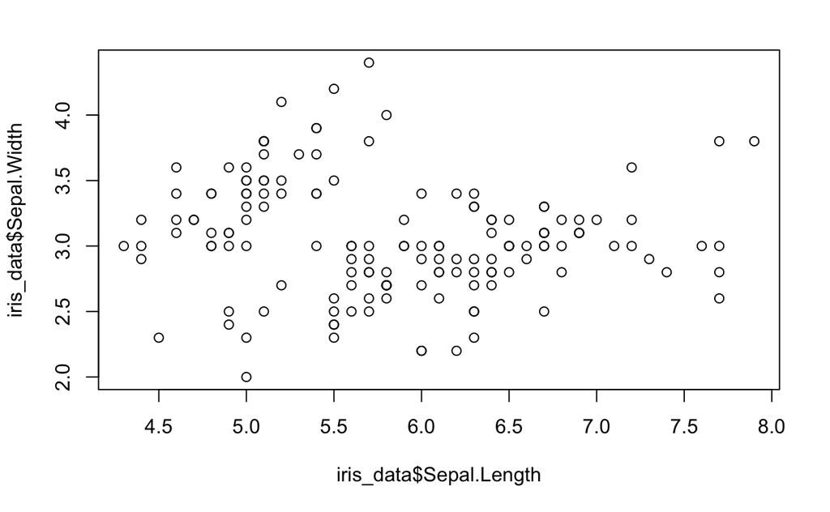

```r
plot(x = iris_data$Sepal.Length, y = iris_data$Sepal.Width)
```

We can change several things about this plot by passing more arguments to the function. Try playing with some of these arguments.

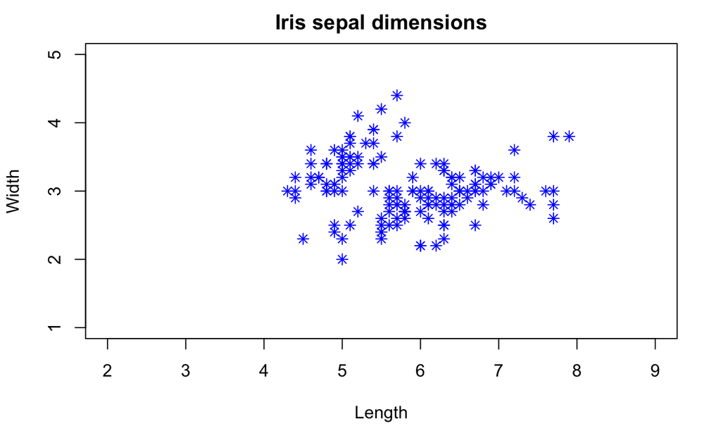

```r
plot(x = iris_data$Sepal.Length, y = iris_data$Sepal.Width,
     main="Iris sepal dimensions",
     type="p",
     xlab="Length",
     ylab="Width",
     pch=8,
     col='blue',
     xlim=c(2,9),
     ylim=c(1,5) )
```

Note that if you can press enter in between arguments, and use spaces or tabs to indent the code. This is far more readable than keeping it on one line and is STRONGLY encouraged.

There are a lot of arguments and options here, so I’ve summarized some of the important ones. In case I’ve missed something or you want to explore, most of the relevant documentation is available in `?par`.

- `main` specifies the main title
- `type` of “p” “l” or “b” will plot points or lines or both
- `xlab` and `ylab` label your axes
- `xlim` and `ylim` set the plot limits
- `pch` picks the points character (try different numbers)
- `lty` is the line type
- `col` sets the color, a vector will plot one color then the other, etc.

Look at `?plot` and `?par` for more, or online.

You can also add on points and lines with `lines()` and `points()`.

```r
plot(x = iris_data$Sepal.Length, y = iris_data$Sepal.Width,
     main="Iris sepal dimensions",
     type="p",
     xlab="Length",
     ylab="Width",
     pch=8,
     col='blue',
     xlim=c(2,9),
     ylim=c(1,5) )
points(x=c(2,9), y=c(1,5), pch=16, cex=5)
```

[figure not shown]

```r
lines(x=c(3, 8),   y=c(2, 4), lty=3, cex=5)
```

# 6 R Resources

The best R resource is google! I can guarantee that any problem you encounter someone else has encountered before, and probably wrote a blog post about it. There is also an active community of R users on Stack Exchange.  
Below are some useful resources

- [RStudio Cheatsheets](https://www.rstudio.com/resources/cheatsheets/)
- [NYU Using R Notebooks](https://drive.google.com/open?id=1tFzzUyzgA7b_1WtqCTMH8ExyI2Zhp8t0)
- Cyclismo
- [Quick-R](http://www.statmethods.net/index.html)
- [Swirlstats](https://swirlstats.com/students.html)